# Relatório 1

Aluno: Pedro H. M. Tashima

## Descrição do dataset

O conjunto de dados "Sistema E-Saude - Perfil de atendimento Odontológico nas Unidades Municipais de Saúde de Curitiba" reúne informações sobre atendimentos realizados por profissionais de odontologia em unidades de saúde. Esses dados mostram o perfil dos usuários atendidos, com informações demográficas, socioeconômicas e de saúde, além de detalhes sobre os procedimentos realizados.

Este contjunto de dados pode ser encontrado no [Portal de Dados Abertos da Prefeitura de Curitiba](https://dadosabertos.curitiba.pr.gov.br/conjuntodado/detalhe?chave=afa9c22d-4fd7-407a-857b-1ab29fc305a3).

|  | Data do Atendimento | Data de Nascimento | Sexo | Código do Tipo de Unidade | Tipo de Unidade | Código da Unidade | Descrição da Unidade | Código do Procedimento | Descrição do Procedimento | Código do CBO | ... | Grupo Comunitário | Meio de Comunicacao | Meio de Transporte | Municício | Bairro | Nacionalidade | cod_usuario | origem_usuario | residente | cod_profissional |
| --- | --- | --- | --- | --- | --- | --- | --- | --- | --- | --- | --- | --- | --- | --- | --- | --- | --- | --- | --- | --- | --- |
| 0 | 01/03/2025 00:02:37 | 24/10/2001 00:00:00 | F | 6 | ODONTOLOGICO | 2639467 | UPA FAZENDINHA | 301060037 | ATENDIMENTO DE URGENCIA EM ATENCAO BASICA | 223208 | ... | NaN | NaN | NaN | CURITIBA | CAMPO DE SANTANA | Brasileira | 2199063 | 1 | 1 | 122756 |
| 1 | 01/03/2025 00:39:57 | 22/01/2003 00:00:00 | F | 6 | ODONTOLOGICO | 2639467 | UPA FAZENDINHA | 101020090 | SELAMENTO PROVISORIO DE CAVIDADE DENTARIA | 223208 | ... | OUTROS | TELEVISAO,RADIO | ONIBUS | CURITIBA | VISTA ALEGRE | Brasileira | 3717342 | 1 | 1 | 122756 |
| 2 | 01/03/2025 00:39:57 | 22/01/2003 00:00:00 | F | 6 | ODONTOLOGICO | 2639467 | UPA FAZENDINHA | 307020029 | CURATIVO DE DEMORA C/ OU S/ PREPARO BIOMECANICO | 223208 | ... | OUTROS | TELEVISAO,RADIO | ONIBUS | CURITIBA | VISTA ALEGRE | Brasileira | 3717342 | 1 | 1 | 122756 |
| 3 | 01/03/2025 00:59:30 | 23/11/1962 00:00:00 | M | 6 | ODONTOLOGICO | 2639467 | UPA FAZENDINHA | 101020090 | SELAMENTO PROVISORIO DE CAVIDADE DENTARIA | 223208 | ... | OUTROS | TELEVISAO,RADIO | ONIBUS | CURITIBA | SAO BRAZ | Brasileira | 4267263 | 1 | 1 | 122756 |
| 4 | 01/03/2025 00:59:30 | 23/11/1962 00:00:00 | M | 6 | ODONTOLOGICO | 2639467 | UPA FAZENDINHA | 301060037 | ATENDIMENTO DE URGENCIA EM ATENCAO BASICA | 223208 | ... | OUTROS | TELEVISAO,RADIO | ONIBUS | CURITIBA | SAO BRAZ | Brasileira | 4267263 | 1 | 1 | 122756 |
| ... | ... | ... | ... | ... | ... | ... | ... | ... | ... | ... | ... | ... | ... | ... | ... | ... | ... | ... | ... | ... | ... |
| 326165 | 06/05/2025 17:29:01 | 15/03/1951 00:00:00 | M | 6 | ODONTOLOGICO | 17108 | UMS CAJURU | 101020104 | ORIENTACAO DE HIGIENE BUCAL | 322405 | ... | NAO PARTICIPA | TELEVISAO | CARRO | CURITIBA | CAJURU | Brasileira | 72343 | 1 | 1 | 41078 |
| 326166 | 30/04/2025 10:14:45 | 25/02/1997 00:00:00 | F | 6 | ODONTOLOGICO | 17094 | UMS CAMARGO | 101020104 | ORIENTACAO DE HIGIENE BUCAL | 322405 | ... | NAO PARTICIPA | TELEVISAO,RADIO,OUTROS | ONIBUS,CARRO | CURITIBA | CAJURU | Brasileira | 12398062 | 1 | 1 | 41584 |
| 326167 | 06/03/2025 07:58:24 | 17/11/1993 00:00:00 | F | 6 | ODONTOLOGICO | 17329 | UMS VILA MACHADO | 307030059 | RASPAGEM ALISAMENTO E POLIMENTO SUPRAGENGIVAIS... | 322405 | ... | NAO PARTICIPA | TELEVISAO,RADIO | ONIBUS,CARRO | CURITIBA | PINHEIRINHO | Brasileira | 1191391 | 1 | 1 | 41660 |
| 326168 | 19/05/2025 15:05:15 | 09/08/1993 00:00:00 | M | 6 | ODONTOLOGICO | 17051 | UMS SOLITUDE PSF | 101020104 | ORIENTACAO DE HIGIENE BUCAL | 322425 | ... | OUTROS | RADIO | ONIBUS | CURITIBA | CAJURU | Brasileira | 12127039 | 1 | 1 | 2736 |
| 326169 | 23/04/2025 17:44:44 | 02/06/1998 00:00:00 | M | 6 | ODONTOLOGICO | 16926 | UMS SANTA FELICIDADE | 101020074 | APLICACAO TOPICA DE FLUOR (INDIVIDUAL POR SESSAO) | 322405 | ... | NAO PARTICIPA | TELEVISAO,RADIO,OUTROS | ONIBUS,CARRO | CURITIBA | SANTA FELICIDADE | Brasileira | 982007 | 1 | 1 | 128958 |

326170 rows × 42 columns

## Limpeza

```
O conjunto de dados antes da limpeza, possui 326170 linhas
```

Pela natureza do sistema de coleta de dados, algumas colunas não são válidas ou utilizadas para atendimentos odontológicos. Outras, são raramente preenchidas. Por esses motivos, colunas totalmente vazias ou com poucos valores não serão utilizadas.

```
Data do Atendimento                                  0
Data de Nascimento                                   0
Sexo                                                 0
Código do Tipo de Unidade                            0
Tipo de Unidade                                      0
Código da Unidade                                    0
Descrição da Unidade                                 0
Código do Procedimento                               0
Descrição do Procedimento                            0
Código do CBO                                        0
Descrição do CBO                                     0
Código do CID                                   326170
Descrição do CID                                326170
Solicitação de Exames                                0
Qtde Prescrita Farmácia Curitibana                   0
Qtde Dispensada Farmácia Curitibana                  0
Qtde de Medicamento Não Padronizado                  0
Encaminhamento para Atendimento Especialista         0
Área de Atuação                                 309099
Desencadeou Internamento                             0
Data do Internamento                            326170
Estabelecimento Solicitante                     326170
Estabelecimento Destino                         326170
CID do Internamento                             326170
Tratamento no Domicílio                          57703
Abastecimento                                    58740
Energia Elétrica                                     0
Tipo de Habitação                                58171
Destino Lixo                                     58665
Fezes/Urina                                      59578
Cômodos                                           7605
Em Caso de Doença                                58301
Grupo Comunitário                                60310
Meio de Comunicacao                              58812
Meio de Transporte                               58611
Municício                                            0
Bairro                                               0
Nacionalidade                                        0
cod_usuario                                          0
origem_usuario                                       0
residente                                            0
cod_profissional                                     0
dtype: int64
```

Apenas as colunas consideradas válidas para a análise foram mantidas, sendo elas:

- Data do Atendimento
- Data de Nascimento
- Sexo
- Descrição da Unidade
- Descrição do Procedimento
- Descrição do CBO
- Energia Elétrica
- Cômodos
- Municício
- Bairro
- Nacionalidade

Uma coluna adicional, "Idade", foi criada a partir da diferença entre a data do atendimento e a data de nascimento.

Linhas com valores nulos e com número de cômodos considerados inválidos (acima de 20) foram removidas.

## Análise Exploratória de Dados

Distribuição dos cômodos das casas dos pacientes:

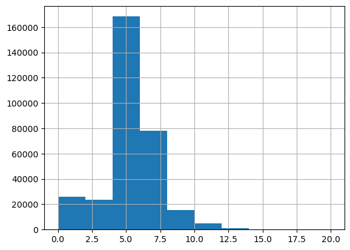

Distribuição de idade dos pacientes:

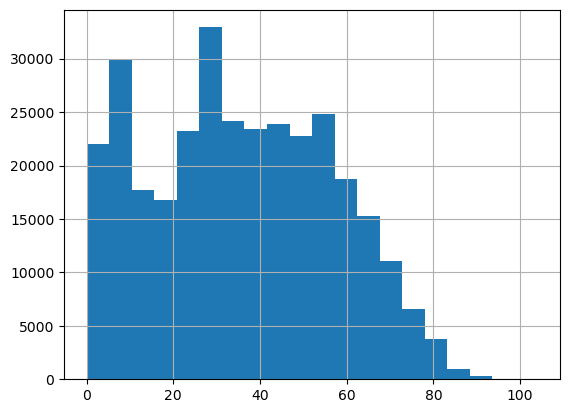

Número de atêndimentos de homens e mulheres:

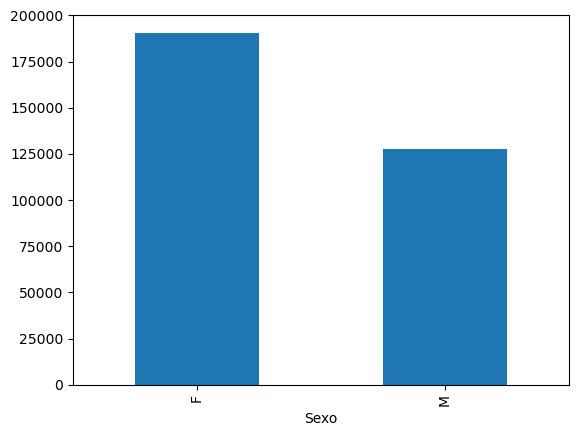

Unidades com mais atendimentos:

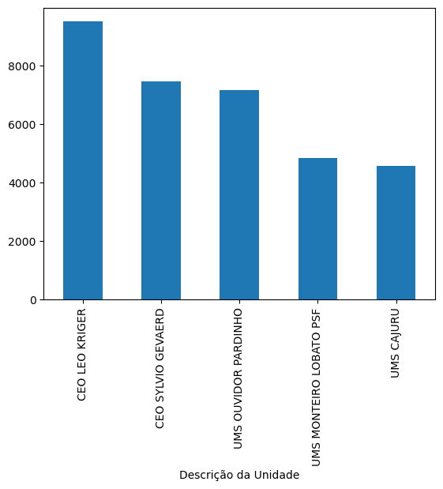

Bairros com mais atendimentos:

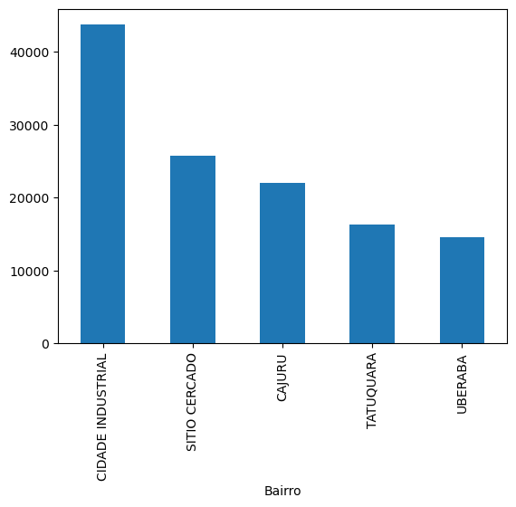

Procedimentos mais comuns:

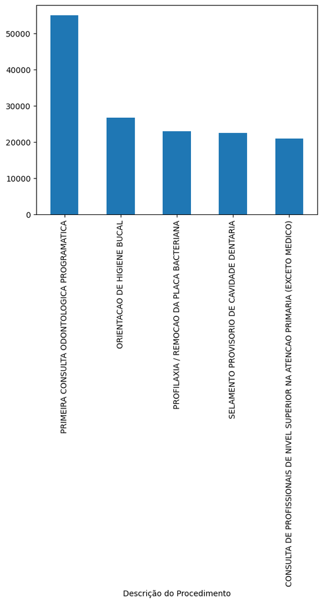

Número de atendimentos em que os pacientes relataram ter energia elétrica:

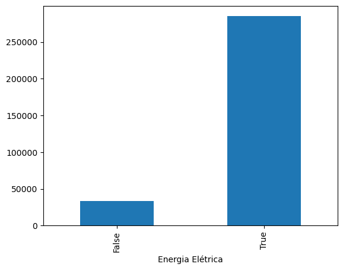

Distribuição da nacionalidade dos pacientes atendidos:

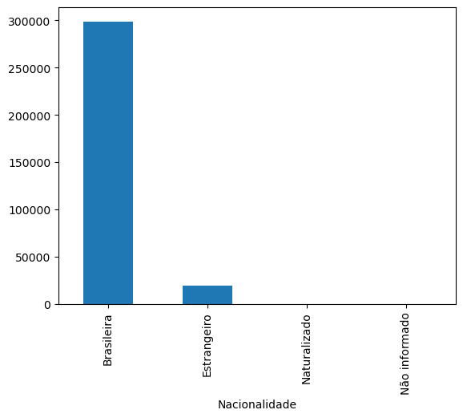

## Perguntas

1. Quais os tipos de atendimentos mais comuns realizados pelos dentistas da rede municipal de saúde?
2. Os procedimentos variam de acordo com o sexo do paciente?
3. Existe correlação entre o número de cômodos da residência e o procedimento realizado?
4. Existe correlação entre ter energia elétrica e o bairro do paciente?
5. Existe correlação entre a idade do paciente e o tipo de procedimento realizado?
6. A nacionalidade do paciente influencia no número de cômodos da residência?
7. Qual a distribuição dos atendimentos ao longo dos meses?